# Data Preprocessing Report

EU Paediatric Clinical Trials - Pipeline Audit

August 15, 2026

# 1. Dataset Overview

50,508

trials in final cache

39,109

source EUCTR

11,399

source CTIS

71

columns

1.5 s

cache load time

The report audits the cache at /Users/rmvpaeme/Repos/active/rshiny_claude/trials_cache.rds. Logs are read from /Users/rmvpaeme/Repos/active/rshiny_claude/data; the SQLite source database is /Users/rmvpaeme/Repos/active/rshiny_claude/data/trials.sqlite.

## Register Mix

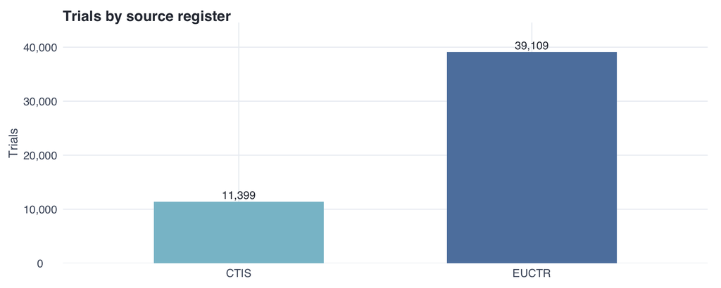

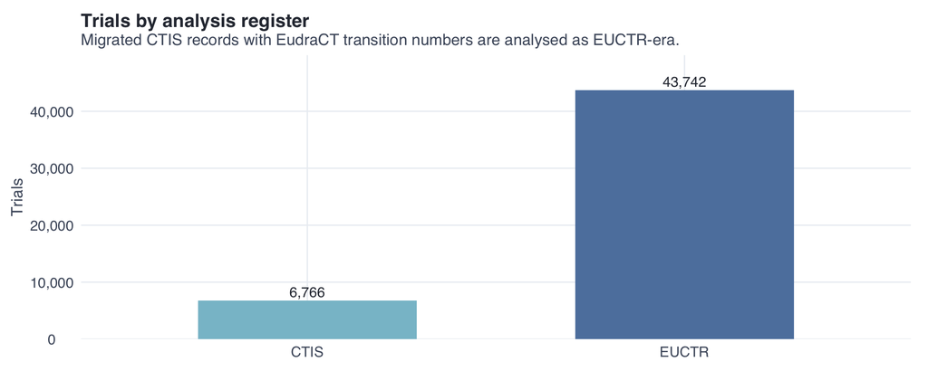

## Key Field Completeness

| Column | Type | Non-missing | Complete (%) |
| --- | --- | --- | --- |
| transition_eudract_number | character | 4633 | 9.2 |
| substance_label | character | 38896 | 77 |
| days_to_decision | numeric | 43881 | 86.9 |
| Full_title | character | 50262 | 99.5 |
| sponsor_type | character | 50273 | 99.5 |
| sponsor_label | character | 50359 | 99.7 |
| phase | character | 50438 | 99.9 |
| _id | character | 50508 | 100 |
| CT_number | character | 50508 | 100 |
| register | character | 50508 | 100 |

[output cut: 10 more lines]

# 2. Deduplication Pipeline

The dedup audit compares raw SQLite row identifiers with the final cache. EUCTR country variants and CTIS amendments are counted directly from raw IDs; cross-register and final removals are the remaining difference between the deduplicated raw universe and the cache.

## Waterfall

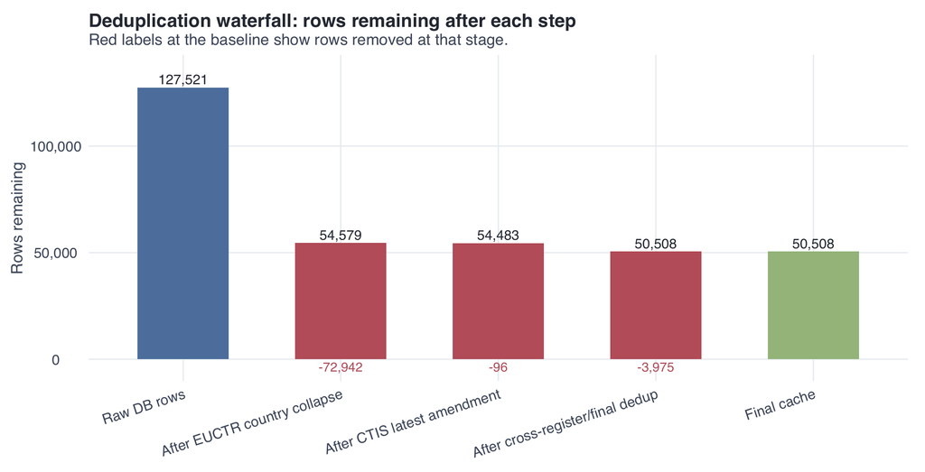

Deduplication stages

| Step | Logic | Rows removed | Rows remaining |
| --- | --- | --- | --- |
| Raw DB | All raw records fetched from SQLite | NA | 127,521 |
| EUCTR country collapse | Strip EUCTR member-state suffix and keep one base trial | 72,942 | 54,579 |
| CTIS latest amendment | Strip CTIS amendment suffix and keep the latest version | 96 | 54,483 |
| Cross-register / final dedup | Prefer CTIS over duplicate EUCTR records and apply final cache exclusions | 3,975 | 50,508 |
| Analysis label | Set analysis_register to EUCTR for migrated CTIS records | 0 | 50,508 |

## EUCTR Country Variants

| Base trial ID | Countries in raw DB | Country variants | Kept in cache |
| --- | --- | --- | --- |
| 2009-011360-10 | 23 | AT, BE, BG, CZ, DE, DK, EE, ES, FI, FR, GB, GR, HU, IE, IT, LT, LV, NL, NO, PT, SE, SI, SK | True |
| 2009-011360-10 | 23 | AT, BE, BG, CZ, DE, DK, EE, ES, FI, FR, GB, GR, HU, IE, IT, LT, LV, NL, NO, PT, SE, SI, SK | True |
| 2009-011360-10 | 23 | AT, BE, BG, CZ, DE, DK, EE, ES, FI, FR, GB, GR, HU, IE, IT, LT, LV, NL, NO, PT, SE, SI, SK | True |
| 2009-011360-10 | 23 | AT, BE, BG, CZ, DE, DK, EE, ES, FI, FR, GB, GR, HU, IE, IT, LT, LV, NL, NO, PT, SE, SI, SK | True |
| 2009-011360-10 | 23 | AT, BE, BG, CZ, DE, DK, EE, ES, FI, FR, GB, GR, HU, IE, IT, LT, LV, NL, NO, PT, SE, SI, SK | True |
| 2009-011360-10 | 23 | AT, BE, BG, CZ, DE, DK, EE, ES, FI, FR, GB, GR, HU, IE, IT, LT, LV, NL, NO, PT, SE, SI, SK | True |
| 2009-011360-10 | 23 | AT, BE, BG, CZ, DE, DK, EE, ES, FI, FR, GB, GR, HU, IE, IT, LT, LV, NL, NO, PT, SE, SI, SK | True |
| 2009-011360-10 | 23 | AT, BE, BG, CZ, DE, DK, EE, ES, FI, FR, GB, GR, HU, IE, IT, LT, LV, NL, NO, PT, SE, SI, SK | True |
| 2009-011360-10 | 23 | AT, BE, BG, CZ, DE, DK, EE, ES, FI, FR, GB, GR, HU, IE, IT, LT, LV, NL, NO, PT, SE, SI, SK | True |
| 2009-011360-10 | 23 | AT, BE, BG, CZ, DE, DK, EE, ES, FI, FR, GB, GR, HU, IE, IT, LT, LV, NL, NO, PT, SE, SI, SK | True |

[output cut: 10 more lines]

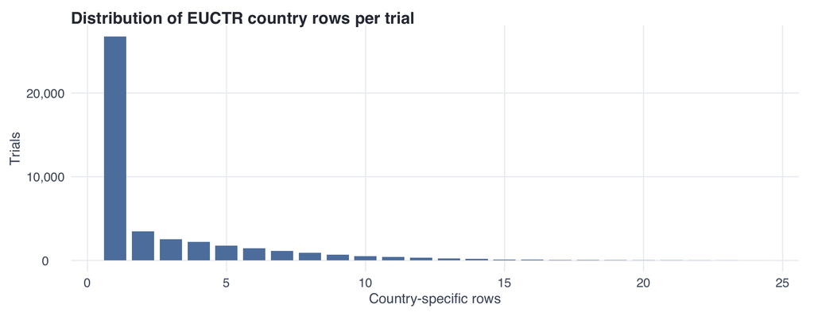

## CTIS Amendment Versions

| Base CTIS ID | Versions in DB | Latest version | Latest raw ID | Latest kept in cache | All versions |
| --- | --- | --- | --- | --- | --- |
| 2022-500030-28 | 2 | 1 | 2022-500030-28-01 | True | 2022-500030-28-00 -&gt; 2022-500030-28-01 |
| 2022-500044-38 | 2 | 1 | 2022-500044-38-01 | True | 2022-500044-38-00 -&gt; 2022-500044-38-01 |
| 2022-500185-94 | 2 | 1 | 2022-500185-94-01 | True | 2022-500185-94-00 -&gt; 2022-500185-94-01 |
| 2022-500228-31 | 2 | 1 | 2022-500228-31-01 | True | 2022-500228-31-00 -&gt; 2022-500228-31-01 |
| 2022-500410-26 | 2 | 1 | 2022-500410-26-01 | True | 2022-500410-26-00 -&gt; 2022-500410-26-01 |
| 2022-500535-36 | 2 | 1 | 2022-500535-36-01 | True | 2022-500535-36-00 -&gt; 2022-500535-36-01 |
| 2022-500536-11 | 2 | 1 | 2022-500536-11-01 | True | 2022-500536-11-00 -&gt; 2022-500536-11-01 |
| 2022-500721-32 | 2 | 1 | 2022-500721-32-01 | True | 2022-500721-32-00 -&gt; 2022-500721-32-01 |
| 2022-501006-34 | 2 | 1 | 2022-501006-34-01 | True | 2022-501006-34-00 -&gt; 2022-501006-34-01 |
| 2022-501312-34 | 2 | 1 | 2022-501312-34-01 | True | 2022-501312-34-00 -&gt; 2022-501312-34-01 |

[output cut: 15 more lines]

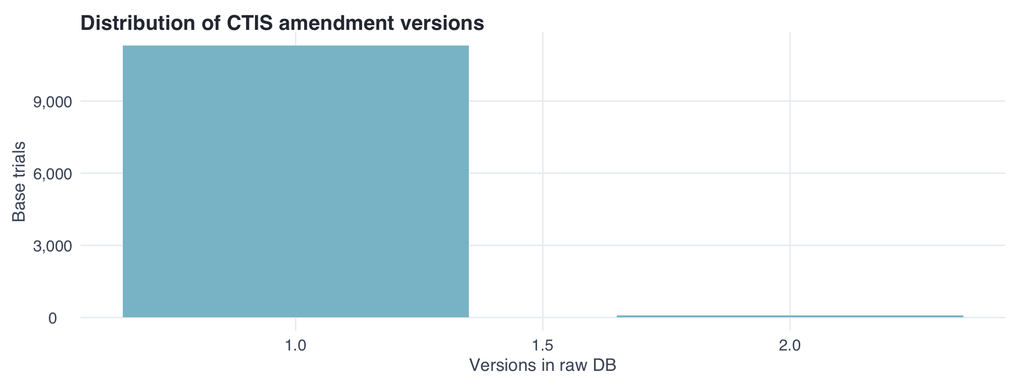

## Cross-Register Checks

| EUCTR ID | CTIS ID | Shared title key | EUCTR status | CTIS status |
| --- | --- | --- | --- | --- |
| 2011-005766-38-PL | 2022-500079-30-00 | a phase 3 multicenter randomized double blind placebo controlled trial to evalua | Completed | Ongoing |
| 2018-000601-22-DE | 2022-500079-30-00 | a phase 3 multicenter randomized double blind placebo controlled trial to evalua | Completed | Ongoing |
| 2011-004844-23-ES | 2022-500090-13-00 | a phase 2 randomized double blind placebo controlled study to evaluate the effec | Completed | Ongoing |
| 2011-004845-42-CZ | 2022-500090-13-00 | a phase 2 randomized double blind placebo controlled study to evaluate the effec | Completed | Ongoing |
| 2008-001936-11-BE | 2022-500257-16-00 | a phase 3 multicenter randomized double blind study to evaluate the safety and e | Completed | Ongoing |
| 2013-001669-17-BE | 2022-500308-23-00 | a randomised controlled assessor blind parallel groups multicentre multinational | Completed | Ongoing |
| 2021-001785-38-AT | 2022-500308-23-00 | a randomised controlled assessor blind parallel groups multicentre multinational | Completed | Ongoing |
| 2018-001133-40-GB | 2022-500488-10-00 | an open label study to evaluate the safety and pharmacokinetics of migalastat hc | Administrative | Ongoing |
| 2018-000265-37-ES | 2022-500694-14-00 | phase 1 2 study investigating safety tolerability pharmacokinetics and prelimina | Completed | Completed |
| 2004-002016-28-AT | 2022-500699-76-00 | a phase 3 randomized double blind placebo controlled study to evaluate the effic | Completed | Ongoing |

[output cut: 90 more lines]

| EUCTR base ID | EUCTR status | CTIS match | Match method |
| --- | --- | --- | --- |
| 2005-003096-20 | Trial now transitioned | 2024-519009-36-01 | transition EudraCT number |
| 2006-003377-27 | Trial now transitioned | 2024-514756-32-00 | transition EudraCT number |
| 2007-000838-39 | Trial now transitioned | 2024-515247-28-00 | transition EudraCT number |
| 2007-001375-11 | Trial now transitioned | 2024-518269-92-00 | transition EudraCT number |
| 2007-003928-37 | Trial now transitioned | 2023-507526-17-00 | transition EudraCT number |
| 2008-002260-33 | Trial now transitioned | 2024-510784-36-00 | transition EudraCT number |
| 2008-006158-16 | Trial now transitioned | 2024-515487-31-00 | transition EudraCT number |
| 2009-015878-35 | Trial now transitioned | 2023-507001-34-00 | transition EudraCT number |
| 2009-016448-38 | Trial now transitioned | 2024-514844-10-00 | transition EudraCT number |
| 2009-017349-77 | Trial now transitioned | 2024-515253-25-00 | transition EudraCT number |

[output cut: 3663 more lines]

# 3. Register, Age, Phase, Status, and Dates

## Age Group

6,734

eligible under 18

46,720

eligible 18 or older

198

unknown age group

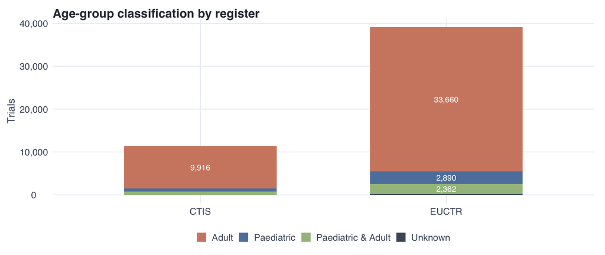

Adult / paediatric classification

| Age group | Trials | % of cache |
| --- | --- | --- |
| Adult | 43,576 | 86.3% |
| Paediatric | 3,590 | 7.1% |
| Paediatric & Adult | 3,144 | 6.2% |
| Unknown | 198 | 0.4% |

## Phase

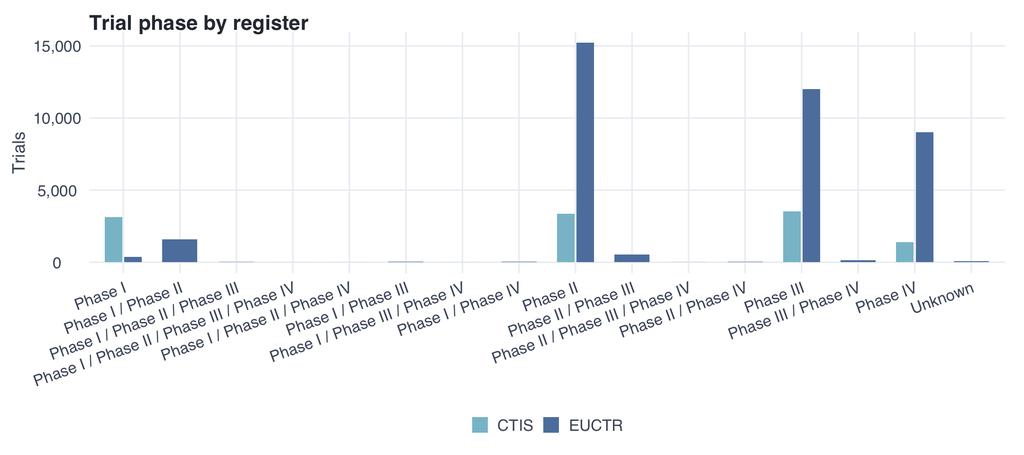

| Register | Raw | Normalised | N trials |
| --- | --- | --- | --- |
| EUCTR | Phase II | Phase II | 15210 |
| EUCTR | Phase III | Phase III | 12001 |
| EUCTR | Phase IV | Phase IV | 9014 |
| CTIS | Therapeutic exploratory (Phase II) | Phase II | 3357 |
| CTIS | Therapeutic confirmatory (Phase III) | Phase III | 3154 |
| EUCTR | Phase I / Phase II | Phase I / Phase II | 1598 |
| CTIS | Therapeutic use (Phase IV) | Phase IV | 1166 |
| CTIS | Human Pharmacology (Phase I)- Other | Phase I | 1040 |
| CTIS | Human Pharmacology (Phase I)- First administration to humans | Phase I | 754 |
| CTIS | Phase I and Phase II (Integrated)- Other | Phase I | 603 |

[output cut: 17 more lines]

## Status

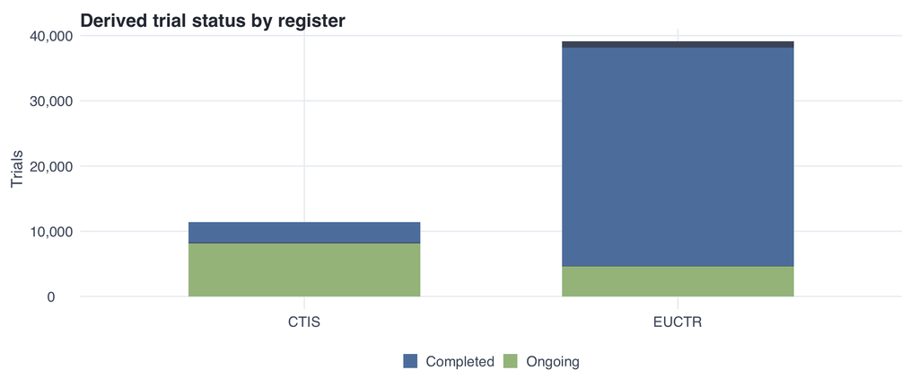

| Register | Raw | Normalised | N trials |
| --- | --- | --- | --- |
| CTIS | Ongoing, recruiting | Ongoing | 3769 |
| CTIS | Ended | Completed | 3116 |
| CTIS | Ongoing, recruitment ended | Ongoing | 2085 |
| CTIS | Authorised, recruitment pending | Ongoing | 1436 |
| CTIS | Authorised, recruiting | Ongoing | 768 |
| CTIS | Not authorised | Not Authorised | 105 |
| CTIS | Temporarily halted | Ongoing | 101 |
| CTIS | Expired | Not Authorised | 10 |
| CTIS | Suspended | Ongoing | 4 |
| CTIS | Under evaluation | Not Authorised | 3 |

[output cut: 9 more lines]

## Dates and Decision Lag

50,508

parsed submission dates

50,487

decision dates

16

completed with no decision date

46

median days to decision

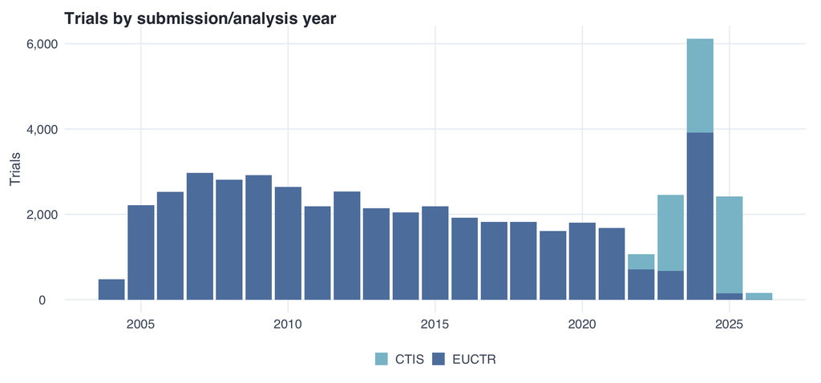

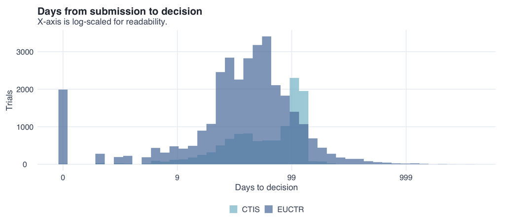

# 4. Field Normalisation Audits

## Country

127,521

country entries

3,909

unique raw values

2,705

unique normalised values

120,653

entries changed

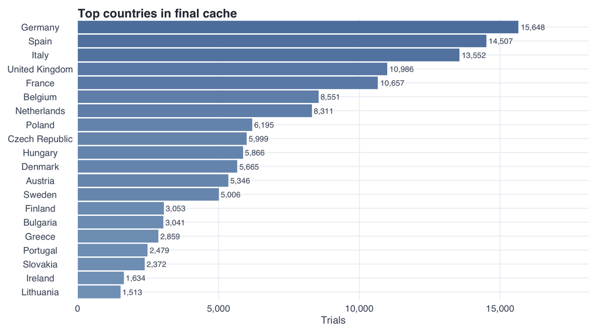

## MedDRA Terms

50,508

MedDRA term entries

12,035

unique raw values

11,121

unique normalised values

7,654

entries changed

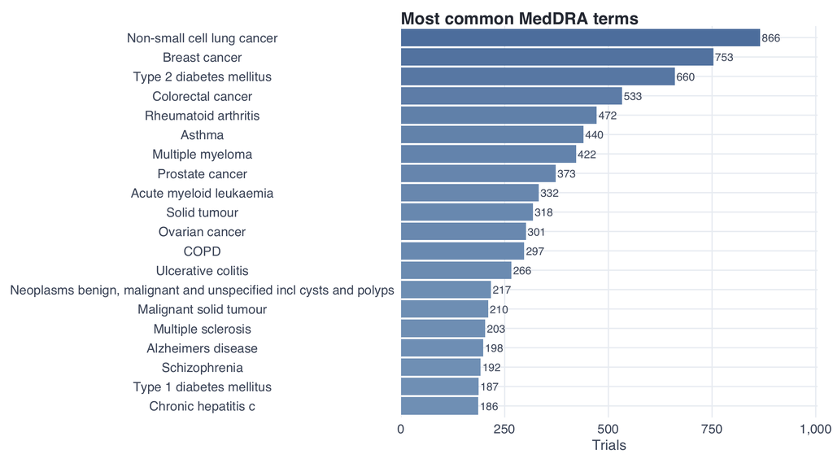

## Organ Class

50,508

organ-class entries

1,268

unique raw values

555

unique normalised values

26,098

entries changed

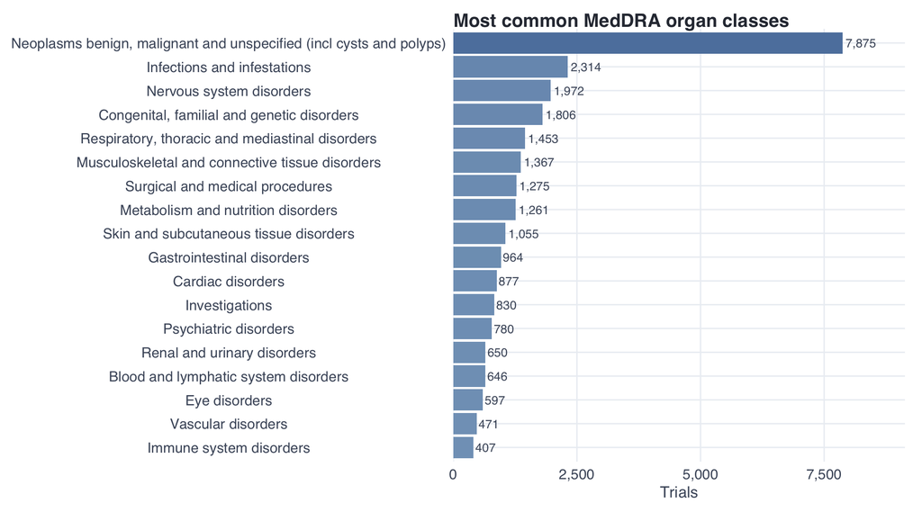

## Sponsor Names

Sponsor labels come from a **model-built canonical registry** (v2), which replaced the deterministic matcher and its ~16,500 committed alias rows. Raw strings are blocked offline, each block is named once with every variant visible, leftover strings are assigned by picking from a candidate list, duplicate entries are merged, and one script emits the app-facing labels.

The label the app displays is resolved by an explicit precedence chain, and the top of it is not the pipeline:

| Rank | Source | Where |
| --- | --- | --- |
| 1 | **Human curation** | `config/review_ledger/review_decisions.csv` |
| 2 | Pipeline canonical | `data/trial_sponsor_labels.csv` |
| 3 | Raw sponsor string | fallback when neither exists |

The ledger is read on every app load and never enters `trials_cache.rds`, so a curator’s decision is live on the next start without a cache rebuild.

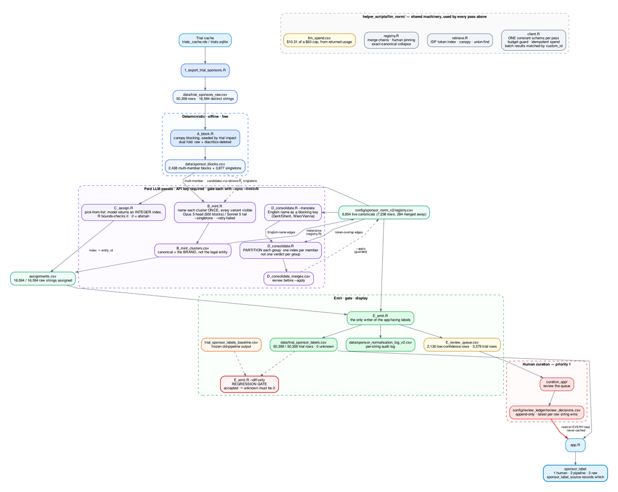

Sponsor normalisation v2. Blue is deterministic and free, violet costs money, green is what the app reads.

16,594

distinct raw strings

50,359

trial rows labelled

6,954

canonical sponsors

2,130

awaiting human review

$10.31

spend to build

**Collapse**  
**16,594** distinct raw strings collapse to **6,954** canonical sponsors — a 2.4x reduction. 0 string(s) carry no canonical. Consolidation merged a further **284** duplicate entries away.

### Who sponsors these trials

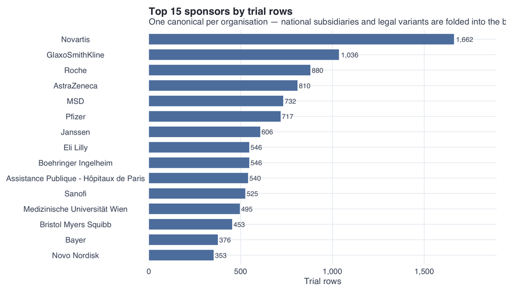

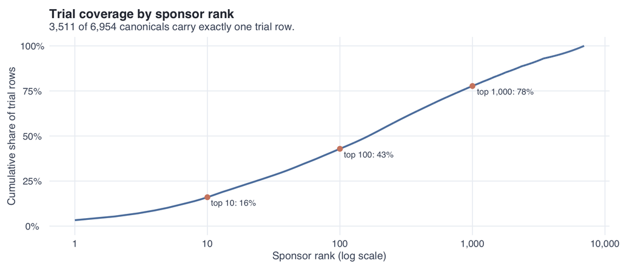

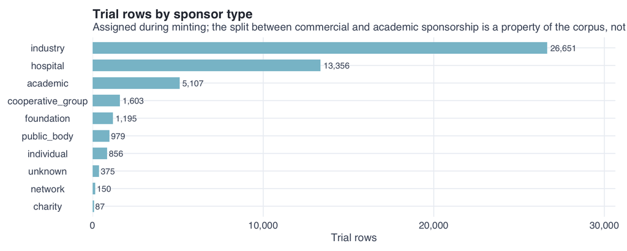

### How confident is the registry

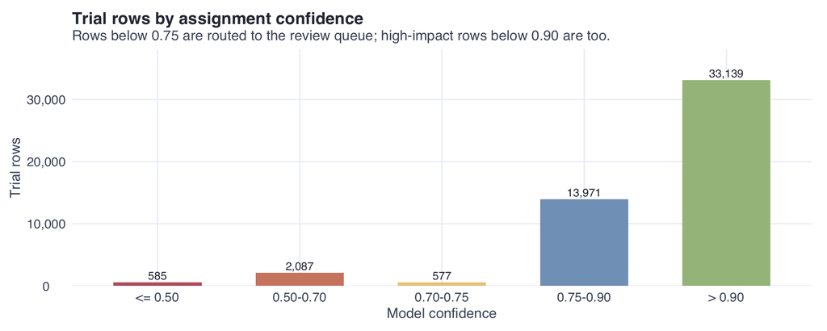

### What still needs a human

**Review queue**  
**2,130** raw strings carrying **3,579** trial rows (7.1% of all rows) are queued for confirmation. These are proposals, not decisions — nothing here changes a displayed label until a reviewer acts on it.

**Human decisions recorded**  
**None yet.** Every label on this page is model output. The precedence chain is wired and tested, so the first curated decision takes effect on the next app start — but nothing has been human-verified so far.

Highest-impact rows awaiting review — curate these first

| raw_sponsor | proposed | confidence | n_trials | review_reason |
| --- | --- | --- | --- | --- |
| Karolinska University Hospital | Karolinska Universitetssjukhuset | 0.88 | 98 | high impact, middling confidence |
| Amsterdam UMC Stichting | Amsterdam UMC | 0.88 | 70 | high impact, middling confidence |
| Merck KGaA | Merck KGaA | 0.85 | 69 | high impact, middling confidence |
| Academic Medical Center | Academic Medical Center | 0.70 | 63 | low confidence |
| Amsterdam UMC | Amsterdam UMC | 0.88 | 60 | high impact, middling confidence |
| University of Cologne | University of Cologne | 0.85 | 53 | high impact, middling confidence |
| University of Dundee | University of Dundee | 0.86 | 47 | high impact, middling confidence |
| ISTITUTO NAZIONALE PER LA CURA TUMORI | Fondazione IRCCS Istituto Nazionale dei Tumori | 0.82 | 44 | high impact, middling confidence |
| Merck Healthcare KGaA | Merck KGaA | 0.85 | 39 | high impact, middling confidence |
| FONDAZIONE CENTRO S. RAFFAELE DEL MONTE TABOR | Fondazione Centro San Raffaele del Monte Tabor | 0.75 | 33 | high impact, middling confidence |
| Vaestra Goetalandsregionen | Västra Götalandsregionen | 0.85 | 32 | high impact, middling confidence |
| Region Skane | Region Skåne | 0.85 | 29 | high impact, middling confidence |
| Cambridge University Hospitals NHS Foundation Trust | Cambridge University Hospitals NHS Foundation Trust | 0.88 | 28 | high impact, middling confidence |
| UMCG | Universitair Medisch Centrum Groningen | 0.85 | 26 | high impact, middling confidence |
| Fundacio De Recerca Clinic Barcelona-Institut D’Investigacions Biomediques August Pi I Sunyer | Institut d’Investigacions Biomèdiques August Pi i Sunyer | 0.86 | 26 | high impact, middling confidence |

### Build cost

LLM spend by pass — $10.31 total, against a $60 cap enforced in code

| Pass | Model | Requests | Cost (USD) |
| --- | --- | --- | --- |
| B_mint | claude-opus-5 | 1,079 | $4.89 |
| B_mint | claude-sonnet-5 | 5,792 | $4.20 |
| D_consolidate | claude-opus-5 | 687 | $1.12 |
| D_translate | claude-sonnet-5 | 361 | $0.09 |

## Substance Names

The substance audit follows the cache-build pipeline: exported trial-substance pairs, pre-filtered/normalised exploratory substances, accepted/review labels, per-trial `substance_label`, and optional review queue rows.

98,842

raw trial-substance pairs

23,595

1,320

review queue rows

40,503

trials in substance log

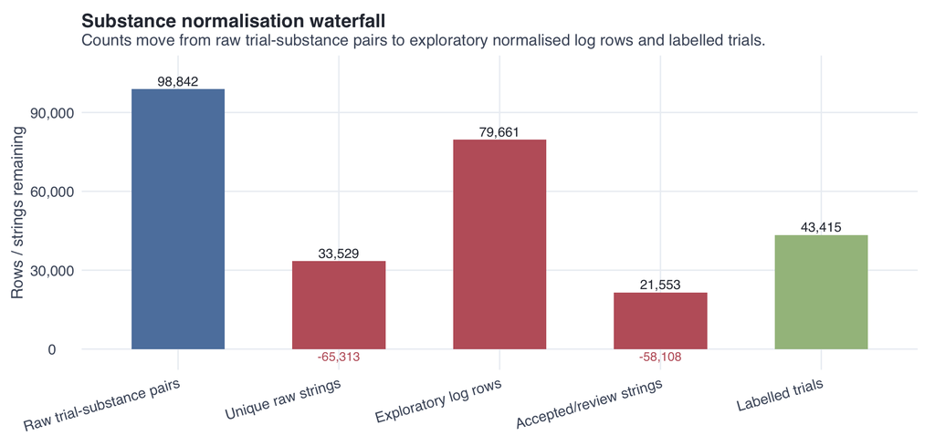

Substance normalisation stage counts

| Step | Count | Removed / collapsed from previous step |
| --- | --- | --- |
| Raw trial-substance pairs | 98,842 | NA |
| Unique raw strings | 33,529 | 65,313 |
| Exploratory log rows | 79,661 | -46,132 |
| Accepted/review strings | 21,553 | 58,108 |
| Labelled trials | 43,415 | -21,862 |

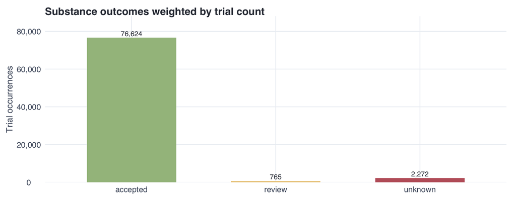

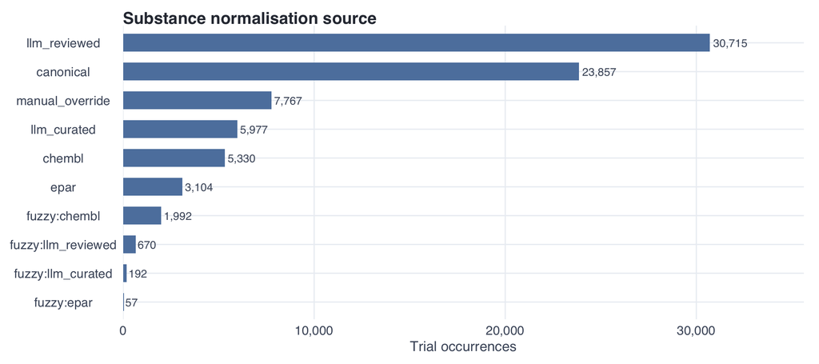

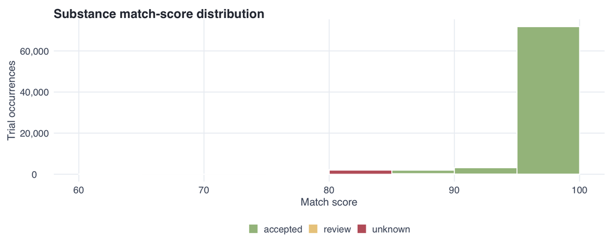

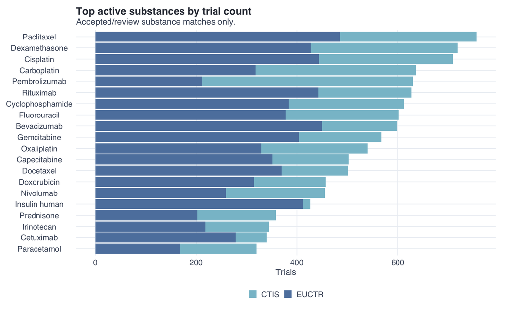

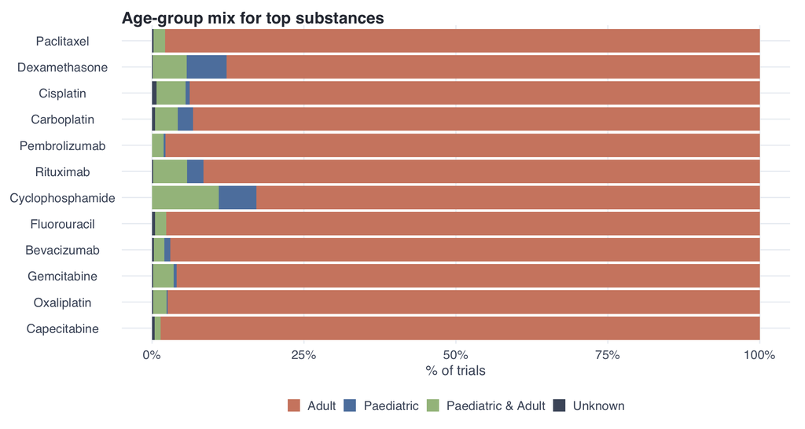

| raw_substance | active_substance_clean | match_status | match_score | match_source | match_reason | n_occurrences | decision | canonical_substance | comment |
| --- | --- | --- | --- | --- | --- | --- | --- | --- | --- |
| Recombinant Neisseria meningitidis group B NadA protein | Recombinant adamts13 | review | 85 | fuzzy:llm_reviewed | fuzzy match (jw similarity 85%) | 13 |  |  |  |
| JNJ-73841937 |  | unknown | 0 |  | no reliable match | 9 |  |  |  |
| mRNA-4157 | Mln-0415 | unknown | 81 | fuzzy:chembl | fuzzy match (jw similarity 81%) | 9 |  |  |  |
| P-Tabletten weiß 7 mm Lichtenstein |  | unknown | 0 |  | no reliable match | 9 |  |  |  |
| JZP598 |  | unknown | 0 |  | no reliable match | 9 |  |  |  |
| BNT327 |  | unknown | 0 |  | no reliable match | 9 |  |  |  |
| AAV2 |  | unknown | 0 |  | no reliable match | 8 |  |  |  |
| XPF-010 | Bmx-010 | unknown | 81 | fuzzy:chembl | fuzzy match (jw similarity 81%) | 8 |  |  |  |
| Diamyd |  | unknown | 0 |  | no reliable match | 7 |  |  |  |
| Bendatax 6 mg | Bendazac | unknown | 83 | fuzzy:chembl | fuzzy match (jw similarity 83%) | 7 |  |  |  |

[output cut: 1310 more lines]

| Trial ID | Raw substance | Clean label | Status | Score | Source | Reason |
| --- | --- | --- | --- | --- | --- | --- |
| 2004-000007-18-SE | salmeterol | Salmeterol | accepted | 100 | canonical | exact canonical substance match |
| 2004-000007-18-SE | fluticasone propionate | Fluticasone | accepted | 100 | canonical | exact canonical substance match |
| 2004-000007-18-SE | Salmeterol | Salmeterol | accepted | 100 | canonical | exact canonical substance match |
| 2004-000015-25-GB | Letrozole | Letrozole | accepted | 100 | canonical | exact canonical substance match |
| 2004-000020-32-BE | Irbesartan | Irbesartan | accepted | 100 | llm_reviewed | alias match (reviewed_queue): 'irbesartan' → 'irbesartan' |
| 2004-000020-32-BE | Hydrochlorothiazide | Hydrochlorothiazide | accepted | 100 | llm_reviewed | alias match (reviewed_queue): 'hydrochlorothiazide' → 'hydrochlorothiazide' |
| 2004-000022-75-ES | Irbesartan | Irbesartan | accepted | 100 | llm_reviewed | alias match (reviewed_queue): 'irbesartan' → 'irbesartan' |
| 2004-000022-75-ES | Ramipril | Ramipril | accepted | 100 | llm_reviewed | alias match (reviewed_queue): 'ramipril' → 'ramipril' |
| 2004-000023-15-AT | Clopidogrel | Clopidogrel | accepted | 100 | canonical | exact canonical substance match |
| 2004-000025-29-BE | Indacaterol 0,05 | Indacaterol | accepted | 100 | canonical | exact canonical substance match |

[output cut: 79651 more lines]

# 5. PIP, Results, and Orphan Flags

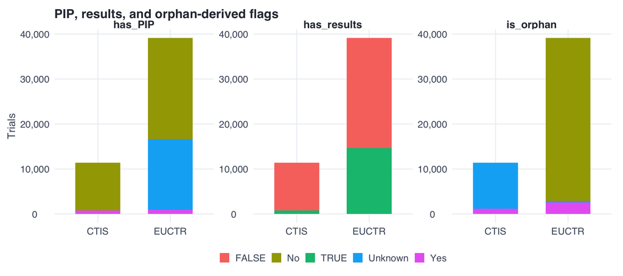

| Flag | register | Value | Trials | % within register |
| --- | --- | --- | --- | --- |
| has_PIP | CTIS | No | 10,635 | 93.3% |
| has_PIP | CTIS | Yes | 764 | 6.7% |
| has_PIP | EUCTR | No | 22,471 | 57.5% |
| has_PIP | EUCTR | Unknown | 15,717 | 40.2% |
| has_PIP | EUCTR | Yes | 921 | 2.4% |
| has_results | CTIS | FALSE | 10,608 | 93.1% |
| has_results | CTIS | TRUE | 791 | 6.9% |
| has_results | EUCTR | FALSE | 24,451 | 62.5% |
| has_results | EUCTR | TRUE | 14,658 | 37.5% |
| is_orphan | CTIS | Unknown | 10,253 | 89.9% |

[output cut: 4 more lines]

# 6. Completeness

| Column | Type | Non-missing | Complete (%) |
| --- | --- | --- | --- |
| authorizedPartI.trialDetails.trialInformation.trialDuration.estimatedRecruitmentStartDate | character | 0 | 0 |
| authorizedApplication.eudraCt.eudraCtCode | character | 4633 | 9.2 |
| transition_eudract_number | character | 4633 | 9.2 |
| authorizedApplication.authorizedPartI.trialDetails.trialInformation.trialDuration.estimatedRecruitmentStartDate | character | 11399 | 22.6 |
| authorizedApplication.authorizedPartI.trialDetails.trialInformation.trialDuration.estimatedEndDate | character | 11399 | 22.6 |
| ctStatus | character | 11399 | 22.6 |
| authorizedApplication.authorizedPartI.sponsors.organisation.name | character | 11399 | 22.6 |
| authorizedApplication.authorizedPartI.sponsors.commercial | character | 11399 | 22.6 |
| authorizedApplication.applicationInfo.decisionDate | character | 11399 | 22.6 |
| authorizedApplication.memberStatesConcerned.firstDecisionDate | character | 11399 | 22.6 |

[output cut: 61 more lines]

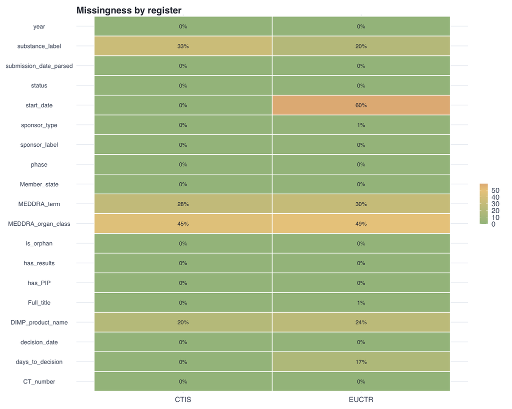

# 7. Data Quality Issues

## Summary

| Severity | Category | Issue | N affected | Suggested_action |
| --- | --- | --- | --- | --- |
| High | Deduplication | Residual cross-register duplicates by shared title key | 100 | Review title-only matches and require corroborating identifiers before automated collapse. |
| High | Deduplication | Transitioned EUCTR trials without a CTIS match in current fallbacks | 43 | Refresh CTIS data and inspect missing transition EudraCT identifiers. |
| High | Deduplication | Duplicate canonical trial IDs in final cache | 0 | Review canonical_trial_id derivation for transition aliases and latest-version preference. |
| High | Status | CTIS numeric status codes outside the current mapping | 0 | Extend CTIS status-code mapping if these codes are valid source values. |
| High | Dates | Completed trials with no decision_date | 16 | Add or audit decision-date fallbacks for completed trials. |
| Medium | Country | Country strings normalised to missing | 0 | Add unresolved country strings to the country lookup or preserve raw values for review. |
| Medium | Organ class | CTIS organ-class codes still stored as raw numbers | 0 | Extend the MedDRA SOC lookup for unresolved numeric CTIS codes. |
| Medium | Identifiers | Canonical trial IDs appearing more than once | 0 | Review duplicate canonical identities and remove duplicate real-world trials. |
| Medium | Sponsor | Sponsor labels still contain legal-entity tokens | 3,726 | Add sponsor aliases for fallback labels that still include legal suffixes. |
| Low | Status | Trials with status 'Other' | 0 | Review raw status values and extend status category patterns where warranted. |

[output cut: 2 more lines]

## Detail Tables

The tables below show examples for issues where example rows are available.

| EUCTR ID | CTIS ID | Shared title key | EUCTR status | CTIS status |
| --- | --- | --- | --- | --- |
| 2011-005766-38-PL | 2022-500079-30-00 | a phase 3 multicenter randomized double blind placebo controlled trial to evalua | Completed | Ongoing |
| 2018-000601-22-DE | 2022-500079-30-00 | a phase 3 multicenter randomized double blind placebo controlled trial to evalua | Completed | Ongoing |
| 2011-004844-23-ES | 2022-500090-13-00 | a phase 2 randomized double blind placebo controlled study to evaluate the effec | Completed | Ongoing |
| 2011-004845-42-CZ | 2022-500090-13-00 | a phase 2 randomized double blind placebo controlled study to evaluate the effec | Completed | Ongoing |
| 2008-001936-11-BE | 2022-500257-16-00 | a phase 3 multicenter randomized double blind study to evaluate the safety and e | Completed | Ongoing |
| 2013-001669-17-BE | 2022-500308-23-00 | a randomised controlled assessor blind parallel groups multicentre multinational | Completed | Ongoing |
| 2021-001785-38-AT | 2022-500308-23-00 | a randomised controlled assessor blind parallel groups multicentre multinational | Completed | Ongoing |
| 2018-001133-40-GB | 2022-500488-10-00 | an open label study to evaluate the safety and pharmacokinetics of migalastat hc | Administrative | Ongoing |
| 2018-000265-37-ES | 2022-500694-14-00 | phase 1 2 study investigating safety tolerability pharmacokinetics and prelimina | Completed | Completed |
| 2004-002016-28-AT | 2022-500699-76-00 | a phase 3 randomized double blind placebo controlled study to evaluate the effic | Completed | Ongoing |

[output cut: 90 more lines]

```
## No unmapped CTIS status codes were detected.
```

```
## No country strings normalised to missing.
```

```
## No unresolved numeric organ-class values.
```

```
## No duplicate canonical trial IDs.
```

| Sponsor label | N trials |
| --- | --- |
| Novartis Pharma Services AG | 238 |
| F. Hoffmann-La Roche Ltd | 114 |
| Dr. Gerhard Mann chem.-pharm. Fabrik GmbH | 103 |
| Novartis Pharma AG | 98 |
| Merck Sharp Dohme Corp., a subsidiary of Merck Co., Inc. | 74 |
| GlaxoSmithKline Research Development Ltd | 62 |
| Pfizer Inc. | 44 |
| AbbVie Deutschland GmbH Co. KG | 42 |
| Gilead Sciences, Inc. | 40 |
| Amgen Inc. | 39 |

[output cut: 20 more lines]

```
## No days_to_decision values above 10 years.
```

```
## No implausible submission years.
```

*Generated by `rmarkdown/preprocessing.Rmd` at 2026-08-15 08:56:27 CEST.*